# Twitter Sampling

Ralf Martin

Last update: October 19 , 2020 - 09:41

=This is still under construction=

# Introduction

The `rtweet` package is great for sampling twitter data. [Here](https://medium.com/@traffordDataLab/exploring-tweets-in-r-54f6011a193d) is a useful guide for some of the basics. [Here](https://www.earthdatascience.org/courses/earth-analytics/get-data-using-apis/use-twitter-api-r/) is another good description.

Here is an example of a search:

```r
tweets <- search_tweets(q = "#ClimateEmergency",
                        n = 10000,
                        include_rts = FALSE,
                        `-filter` = "replies",
                        lang = "en",retryonratelimit=TRUE)
```

```
## retry on rate limit...
## waiting about 14 minutes...
```

```r
head(tweets)
```

```
## # A tibble: 6 x 90
##   user_id status_id created_at          screen_name text  source
##   <chr>   <chr>     <dttm>              <chr>       <chr> <chr>
## 1 279977~ 13181121~ 2020-10-19 08:50:09 traceyggor  "#73~ Twitt~
## 2 932615~ 13181117~ 2020-10-19 08:48:21 T_Minus30   "Ple~ Twitt~
## 3 114038~ 13181117~ 2020-10-19 08:48:17 XRCamden    "Mur~ Twitt~
## 4 114038~ 13176106~ 2020-10-17 23:37:12 XRCamden    "“Re~ Twitt~
## 5 114038~ 13175196~ 2020-10-17 17:35:32 XRCamden    "Is ~ Twitt~
## 6 114038~ 13165081~ 2020-10-14 22:36:20 XRCamden    "Ima~ Twitt~
## # ... with 84 more variables: display_text_width <dbl>,
## #   reply_to_status_id <chr>, reply_to_user_id <chr>,
## #   reply_to_screen_name <chr>, is_quote <lgl>, is_retweet <lgl>,
## #   favorite_count <int>, retweet_count <int>, quote_count <int>,
## #   reply_count <int>, hashtags <list>, symbols <list>, urls_url <list>,
## #   urls_t.co <list>, urls_expanded_url <list>, media_url <list>,
## #   media_t.co <list>, media_expanded_url <list>, media_type <list>,
## #   ext_media_url <list>, ext_media_t.co <list>, ext_media_expanded_url <list>,
## #   ext_media_type <chr>, mentions_user_id <list>, mentions_screen_name <list>,
## #   lang <chr>, quoted_status_id <chr>, quoted_text <chr>,
## #   quoted_created_at <dttm>, quoted_source <chr>, quoted_favorite_count <int>,
## #   quoted_retweet_count <int>, quoted_user_id <chr>, quoted_screen_name <chr>,
## #   quoted_name <chr>, quoted_followers_count <int>,
## #   quoted_friends_count <int>, quoted_statuses_count <int>,
## #   quoted_location <chr>, quoted_description <chr>, quoted_verified <lgl>,
## #   retweet_status_id <chr>, retweet_text <chr>, retweet_created_at <dttm>,
## #   retweet_source <chr>, retweet_favorite_count <int>,
## #   retweet_retweet_count <int>, retweet_user_id <chr>,
## #   retweet_screen_name <chr>, retweet_name <chr>,
## #   retweet_followers_count <int>, retweet_friends_count <int>,
## #   retweet_statuses_count <int>, retweet_location <chr>,
## #   retweet_description <chr>, retweet_verified <lgl>, place_url <chr>,
## #   place_name <chr>, place_full_name <chr>, place_type <chr>, country <chr>,
## #   country_code <chr>, geo_coords <list>, coords_coords <list>,
## #   bbox_coords <list>, status_url <chr>, name <chr>, location <chr>,
## #   description <chr>, url <chr>, protected <lgl>, followers_count <int>,
## #   friends_count <int>, listed_count <int>, statuses_count <int>,
## #   favourites_count <int>, account_created_at <dttm>, verified <lgl>,
## #   profile_url <chr>, profile_expanded_url <chr>, account_lang <lgl>,
## #   profile_banner_url <chr>, profile_background_url <chr>,
## #   profile_image_url <chr>
```

# Climate tweets & climate hoaxism

```r
library(lubridate)
library(dplyr)

climatetweets=read.csv("https://www.dropbox.com/s/mz6094zvx1ke4r2/climatetweets.csv?dl=1")
climatetweets=climatetweets %>% mutate(created_at= as_datetime(as.character(created_at)))
```

Note this is a really big dataset with information on 713720 tweets so downloading this might take a while and also requires a lot of harddrive and memory space.

Let’s compute some figures on the basis of this data.

```r
library(lubridate)

start.date = ymd_hms("2020-01-01 00:00:00")
#start.date = ymd_hms("2020-01-01 00:00:00")
end.date   = as_datetime(now()+days(1)) #ymd_hms("2020-04-02 01:00:00")
#end.date   = ymd_hms("2020-04-04 01:00:00")
breaks = seq(start.date, end.date, "24 hours")

breaksweeks = seq(start.date, end.date, "1 week")
climatetweets = climatetweets %>% mutate(week= cut(created_at, breaks=breaksweeks),climatehoax_id=climatehoax_id=="true")

library(data.table)
fcomb=climatetweets

library(stringr)
fcomb=fcomb%>%mutate(usid=str_trim(state2dig)!="",climatehoax_id=as.numeric(climatehoax_id))
fcomb=fcomb%>%mutate(country=ifelse(usid==TRUE,"US",ifelse(str_trim(ukid)!="","UK","other"))   )


scomb=fcomb %>%group_by(week,country)%>% dplyr::summarise(climatetweets=n(),climatehoax_id=sum(climatehoax_id,na.rm = T))
scomb=scomb%>%mutate(hoaxsh=climatehoax_id/climatetweets*100)

#test=climatetweets %>% filter(climatehoax_id==T)

scomb=scomb %>% filter(is.na(country)==FALSE & is.na(week)==FALSE) %>% ungroup() %>%mutate(week=as.Date(week))
#write.csv(scomb, file="../chseries.csv")
```

Note that these tweets have been sampled over time at differing sampling rates; i.e. for a while (starting in April) I sampled tweets every two hours. More recently I am only sampling once or twice a day. Hence, over time we can only compare statistics that are not affected by this.

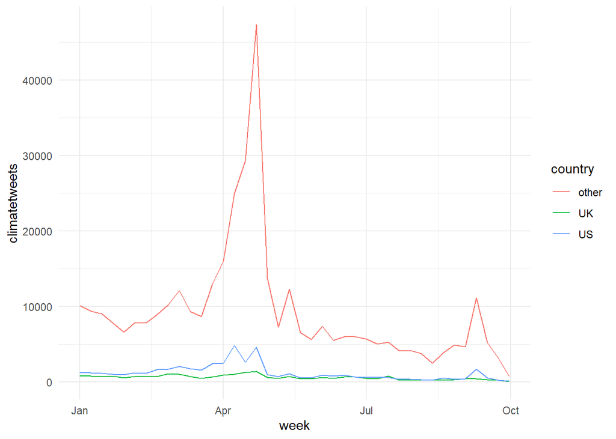

```r
library(ggplot2)
ggplot(scomb,aes(x=week,y=climatetweets,color=country)) +  geom_line() +theme_minimal()
```

For instance, we can look at the weekly ratio of climate hoax tweets (identified by using the hashtag `#climatehoax`) over all climate related tweets. This is shown in the following figure

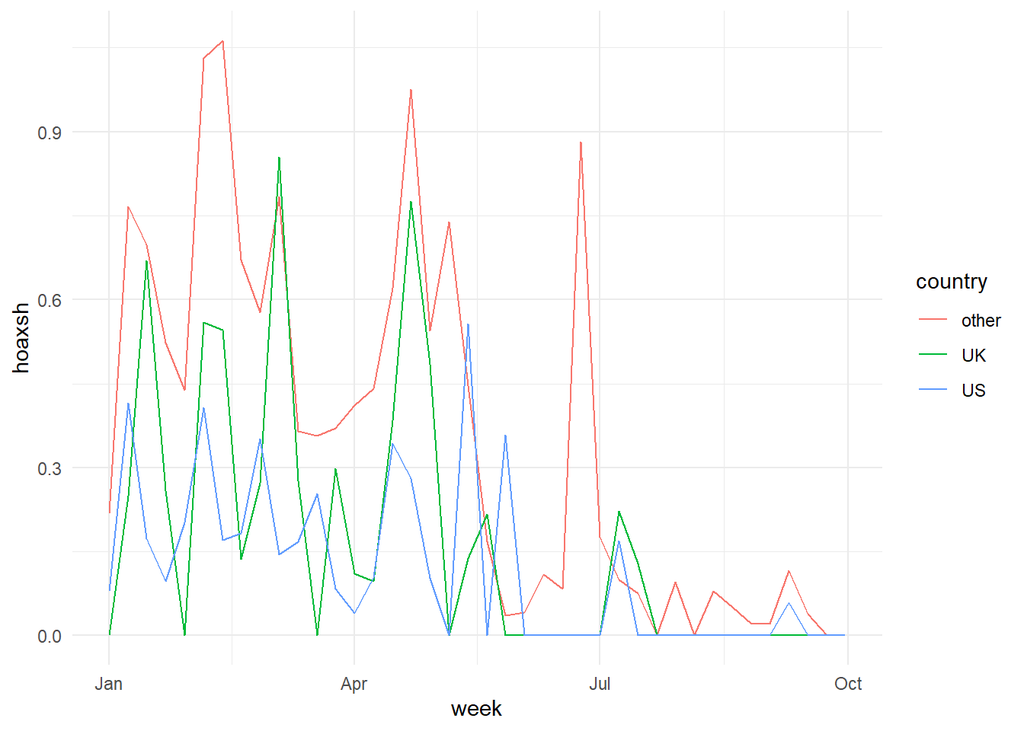

```r
library(ggplot2)
ggplot(scomb,aes(x=week,y=hoaxsh,color=country)) +  geom_line() +theme_minimal()
```

A first glance would suggest that climate hoaxism is on the delicline over 2020.